# Project 2

Alex Zhang

2022-11-11

```r
logodds_plot <- function(data, num_bins, bin_method,
                         x_name, y_name, grouping = NULL, reg_formula = y ~ x){

  if(is.null(grouping)){
    dat <- data.frame(x = data %>% pull(x_name),
                      y = data %>% pull(y_name),
                      group = 1)
  } else {
    dat <- data.frame(x = data %>% pull(x_name),
                      y = data %>% pull(y_name),
                      group = data %>% pull(grouping))
  }

  if(bin_method == "equal_size"){
    logodds_table <- dat %>%
      drop_na() %>%
      arrange(group, x) %>%
      group_by(group) %>%
      mutate(obs = y,
             bin = rep(1:num_bins,
                       each=ceiling(n()/num_bins))[1:n()]) %>%
      group_by(bin, group) %>%
      summarize(mean_x = mean(x),
                prop = mean(c(obs, 0.5)),
                num_obs = n()) %>%
      ungroup() %>%
      mutate(logodds = log(prop/(1 - prop)))
  } else {
    logodds_table <- dat %>%
      drop_na() %>%
      group_by(group) %>%
      mutate(obs = y,
             bin = cut(x,
                       breaks = num_bins,
                       labels = F)) %>%
      group_by(bin, group) %>%
      summarize(mean_x = mean(x),
                prop = mean(c(obs, 0.5)),
                num_obs = n()) %>%
      ungroup() %>%
      mutate(logodds = log(prop/(1 - prop)))
  }

  if(is.null(grouping)){
    logodds_table %>%
      ggplot(aes(x = mean_x,
                 y = logodds)) +
      geom_point(size=2) +
      geom_smooth(se=F, method="lm", formula = reg_formula) +
      theme_bw() +
      labs(x = x_name,
           y = "Empirical log odds") +
      theme(text = element_text(size=25))
  } else {
    logodds_table %>%
      ggplot(aes(x = mean_x,
                 y = logodds,
                 color = group,
                 shape = group)) +
      geom_point(size=2) +
      geom_smooth(se=F, method="lm", formula = reg_formula) +
      theme_bw() +
      labs(x = x_name,
           y = "Empirical log odds",
           color = grouping,
           shape = grouping) +
      theme(text = element_text(size=25))
  }

}
```

```r
logmean_plot <- function(data, num_bins, bin_method,
                         x, y, grouping = NULL, reg_formula = y ~ x){

  if(is.null(grouping)){
    dat <- data.frame(x = data[,x],
                      y = data[,y],
                      group = 1)
  } else {
    dat <- data.frame(x = data[,x],
                      y = data[,y],
                      group = data[,grouping])
  }

  if(bin_method == "equal_size"){
    log_table <- dat %>%
      drop_na() %>%
      arrange(group, x) %>%
      group_by(group) %>%
      mutate(obs = y,
             bin = rep(1:num_bins,
                       each=ceiling(n()/num_bins))[1:n()]) %>%
      group_by(bin, group) %>%
      summarize(mean_x = mean(x),
                mean_y = mean(obs),
                num_obs = n()) %>%
      ungroup() %>%
      mutate(log_mean = log(mean_y))
  } else {
    log_table <- dat %>%
      drop_na() %>%
      group_by(group) %>%
      mutate(obs = y,
             bin = cut(x,
                       breaks = num_bins,
                       labels = F)) %>%
      group_by(bin, group) %>%
      summarize(mean_x = mean(x),
                mean_y = mean(obs),
                num_obs = n()) %>%
      ungroup() %>%
      mutate(log_mean = log(mean_y))
  }

  if(is.null(grouping)){
    log_table %>%
      ggplot(aes(x = mean_x,
                 y = log_mean)) +
      geom_point(size=2.5) +
      geom_smooth(se=F, method="lm", formula = reg_formula) +
      theme_bw() +
      labs(x = x,
           y = "Empirical log mean count") +
      theme(text = element_text(size=25))
  } else {
    log_table %>%
      ggplot(aes(x = mean_x,
                 y = log_mean,
                 color = group,
                 shape = group)) +
      geom_point(size=2.5) +
      geom_smooth(se=F, method="lm", formula = reg_formula) +
      theme_bw() +
      labs(x = x,
           y = "Empirical log mean count",
           color = grouping,
           shape = grouping) +
      theme(text = element_text(size=25))
  }

}
```

## Section 1: Introduction

## Section 2: Data

```r
serengeti <- serengeti %>%
  drop_na()
glimpse(serengeti)
```

```
## Rows: 966
## Columns: 15
## $ siteID                  <chr> "B06", "B06", "B06", "B06", "B06", "B06", "B06…
## $ date                    <chr> "2012-01-01", "2012-01-09", "2012-01-17", "201…
## $ site.date               <chr> "B062012-01-01", "B062012-01-09", "B062012-01-…
## $ ndvi                    <dbl> 0.7553498, 0.6792881, 0.5774416, 0.5225141, 0.…
## $ gazelleThomsons.count   <int> 0, 0, 0, 0, 0, 1, 0, 0, 0, 0, 0, 0, 0, 0, 0, 5…
## $ gazelleThomsons.present <int> 0, 0, 0, 0, 0, 1, 0, 0, 0, 0, 0, 0, 0, 0, 0, 1…
## $ topi.count              <int> 0, 0, 0, 0, 0, 0, 0, 0, 1, 0, 0, 0, 0, 0, 0, 0…
## $ topi.present            <int> 0, 0, 0, 0, 0, 0, 0, 0, 1, 0, 0, 0, 0, 0, 0, 0…
## $ zebra.count             <int> 0, 0, 0, 0, 16, 47, 118, 26, 6, 2, 1, 0, 1, 1,…
## $ zebra.present           <int> 0, 0, 0, 0, 1, 1, 1, 1, 1, 1, 1, 0, 1, 1, 1, 0…
## $ fire                    <int> 0, 0, 0, 0, 0, 0, 0, 0, 0, 0, 0, 0, 0, 0, 0, 0…
## $ amRivDist               <dbl> 4135.915, 4135.915, 4135.915, 4135.915, 4135.9…
## $ TM100                   <int> 0, 0, 0, 0, 0, 0, 0, 0, 0, 0, 0, 0, 0, 0, 0, 0…
## $ LriskDry                <dbl> 0.001216255, 0.001216255, 0.001216255, 0.00121…
## $ T50                     <int> 500, 500, 500, 500, 500, 500, 500, 500, 500, 5…
```

After trying to drop the missing data, it still exists 966 rows and 15 columns which indicate there is no missing data.

Based on the summary of the data, each row it represents the information for a site with specific date. Each row also contains the the count and appearance of certain species and some other environmental factors. There are total 966 rows and 15 columns. The data set contains information about the site id, recorded date, gazalle’s count and appearance, topi count, zebra count, and other environmental factors like whether having wildfire or having enough vegetation.

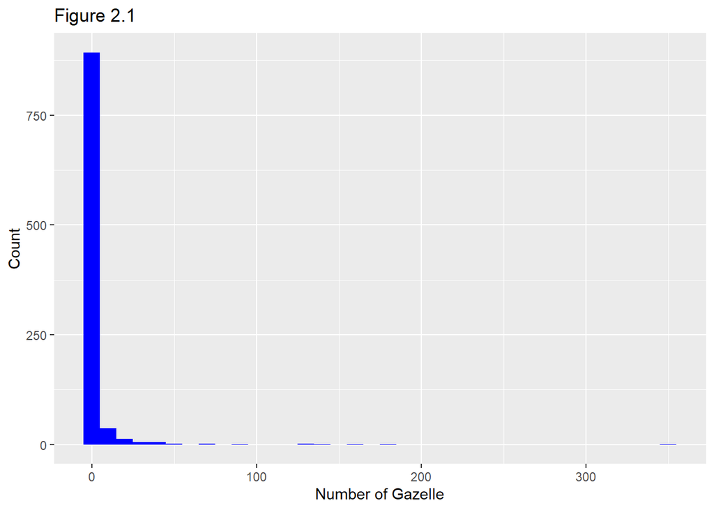

```r
ggplot(data = serengeti, aes(x = gazelleThomsons.count)) + geom_histogram(binwidth = 10, fill = "blue") + labs(title = "Figure 2.1", x = "Number of Gazelle", y = "Count")
```

Based on Figure 2.1, we can observe that the number of gazelle Thomsons in these sites ar 0 in most sites. There are also hundreds of gazelle Thomsons in some specific areas.

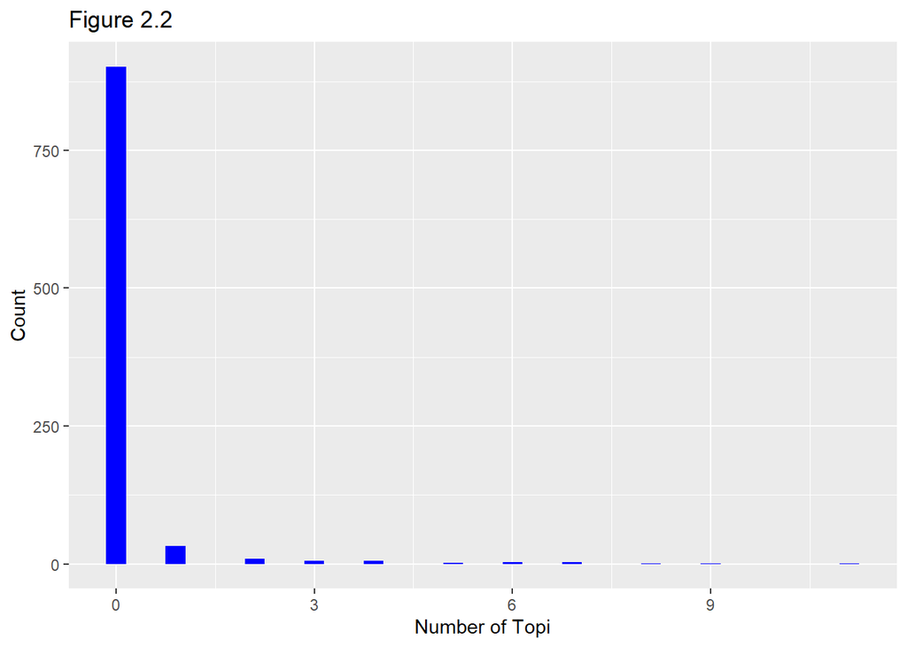

```r
ggplot(data = serengeti, aes(x = topi.count)) + geom_histogram(binwidth = 0.3, fill = "blue") + labs(title = "Figure 2.2", x = "Number of Topi", y = "Count")
```

Based on Figure 2.2, it shows that in most recorded sites, the number of topi is 0 and there are few of them in some specific sites.

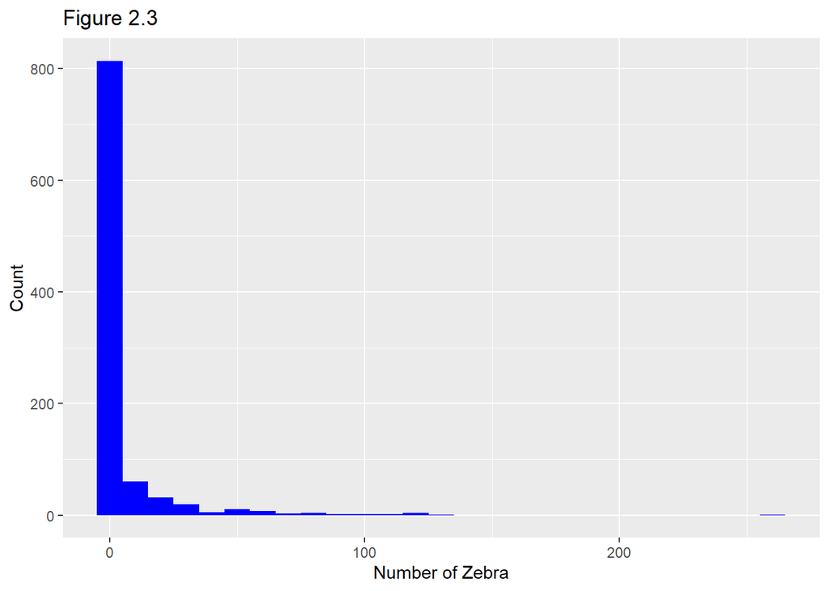

```r
ggplot(data = serengeti, aes(x = zebra.count)) + geom_histogram(binwidth = 10, fill = "blue") + labs(title = "Figure 2.3", x = "Number of Zebra", y = "Count")
```

Based on Figure 2.3, we can also conclude that the number of zebra in most sites is 0.

[output not shown]

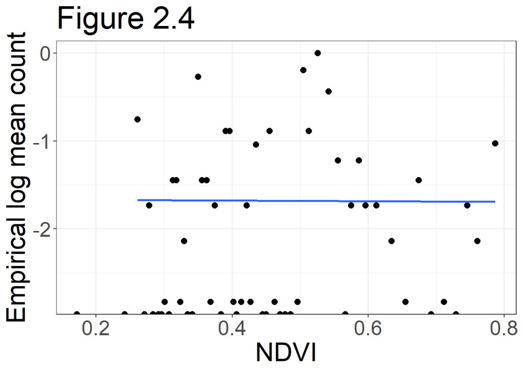

```r
logmean_plot(data = serengeti, 60, "equal_size","ndvi", "topi.count", reg_formula = y ~ x) + labs(title = "Figure 2.4", x = "NDVI")
```

As showed from Figure 2.4, the relationship between the number of topi and the vegetation condition is also linear since points are bouncing around the linear which means no transformation needed.

[output not shown]

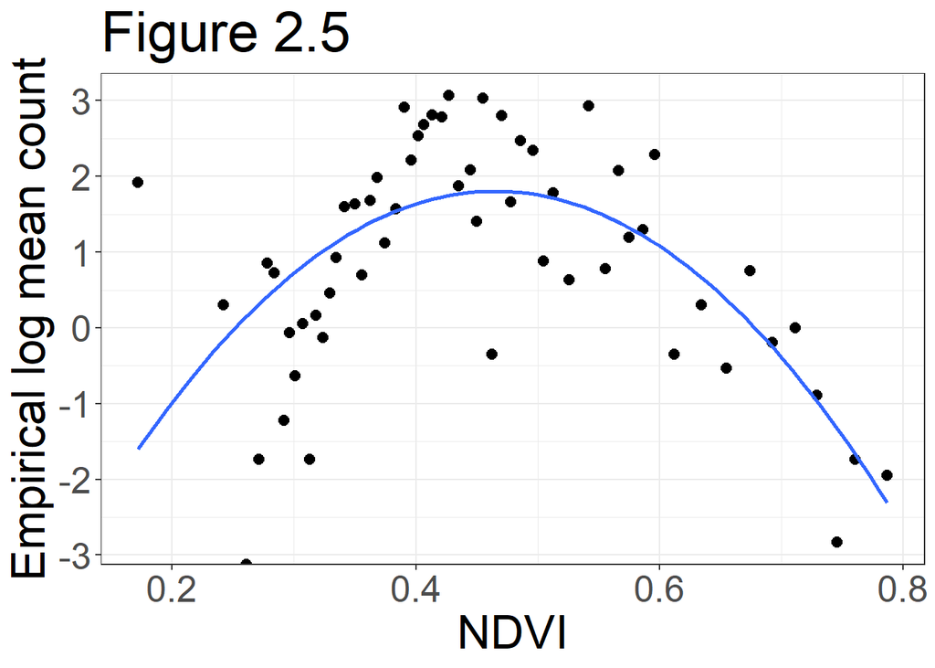

```r
logmean_plot(data = serengeti, 60, "equal_size","ndvi", "zebra.count", reg_formula = y ~ poly(x,2)) + labs(title = "Figure 2.5", x = "NDVI")
```

Based on Figure 2.5, the relationship between the number of zebra and the vegetation condition is nonlinear. So the polynomial transformation with a power of two is needed.

[output not shown]

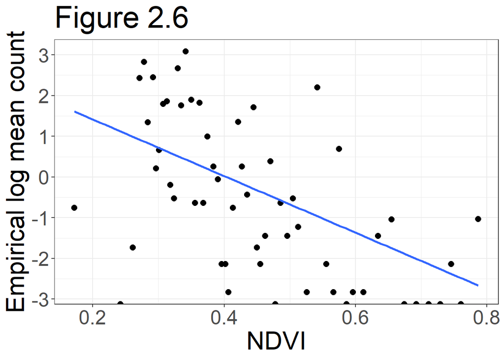

```r
logmean_plot(data = serengeti, 60, "equal_size","ndvi", "gazelleThomsons.count", reg_formula = y ~ x) + labs(title = "Figure 2.6", x = "NDVI")
```

Based on Figure 2.6, the relationship between vegetation condition and the number of gazelle can be defined as linear since there is no explicit shape. No transformation is required.

[output not shown]

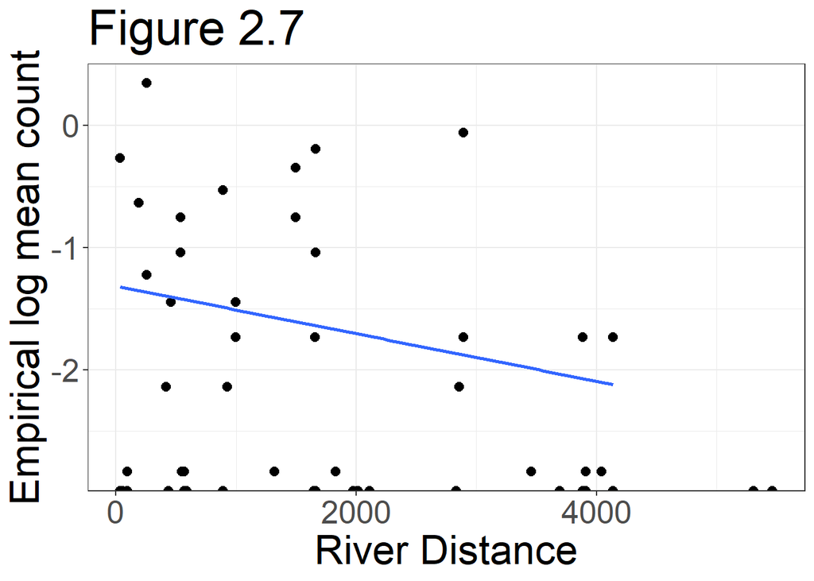

```r
logmean_plot(data = serengeti, 60, "equal_size",x = "amRivDist",  y = "topi.count", reg_formula = y ~ (x)) + labs(title = "Figure 2.7", x = "River Distance")
```

Based on Figure 2.7, ideally no transformation is needed for the relation between river distance and the number of topi. However, since the numbers for river distance are really large, outweighted other variablers, I choose to do the log transformation on it.

[output not shown]

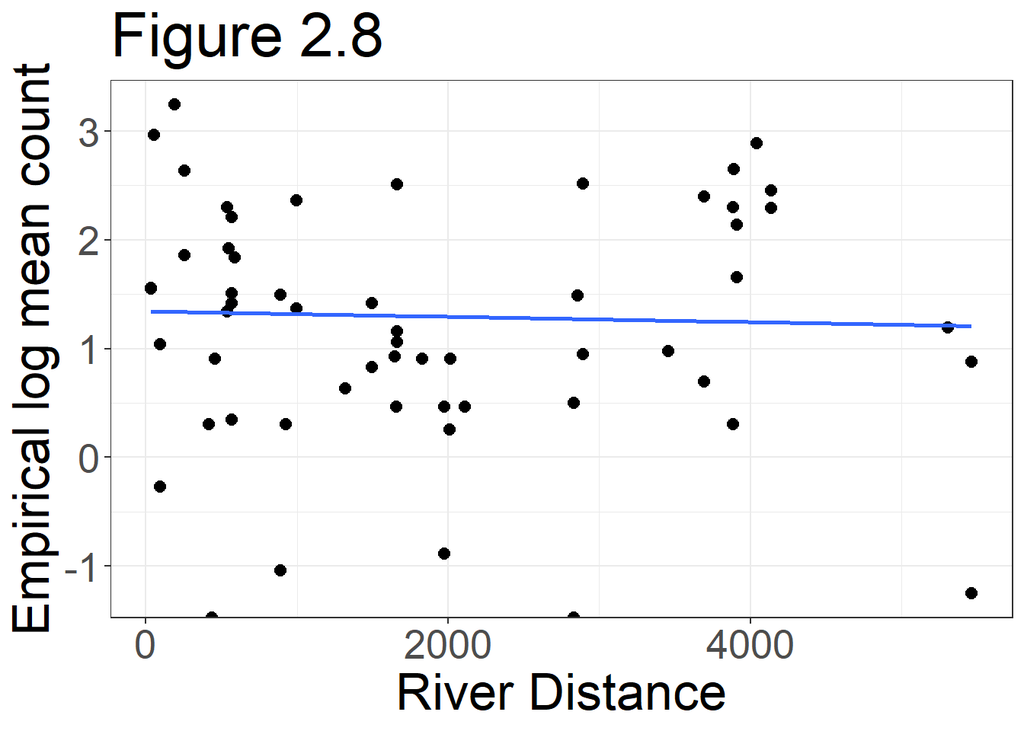

```r
logmean_plot(data = serengeti, 60, "equal_size",x = "amRivDist",  y = "zebra.count", reg_formula = y ~ x) + labs(title = "Figure 2.8", x = "River Distance")
```

[output not shown]

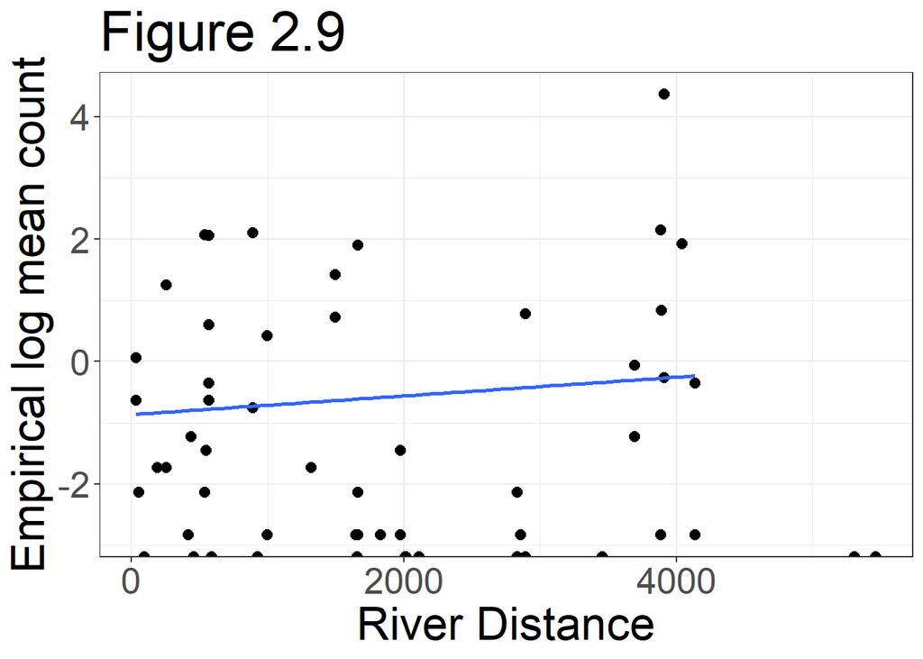

```r
logmean_plot(data = serengeti, 60, "equal_size", x = "amRivDist", y = "gazelleThomsons.count", reg_formula = y ~ (x)) +  labs(title = "Figure 2.9", x = "River Distance")
```

Based on Figure 2.9, having a log transformation is reasonable for the relation between the number of gazelle and the river distance.

[output not shown]

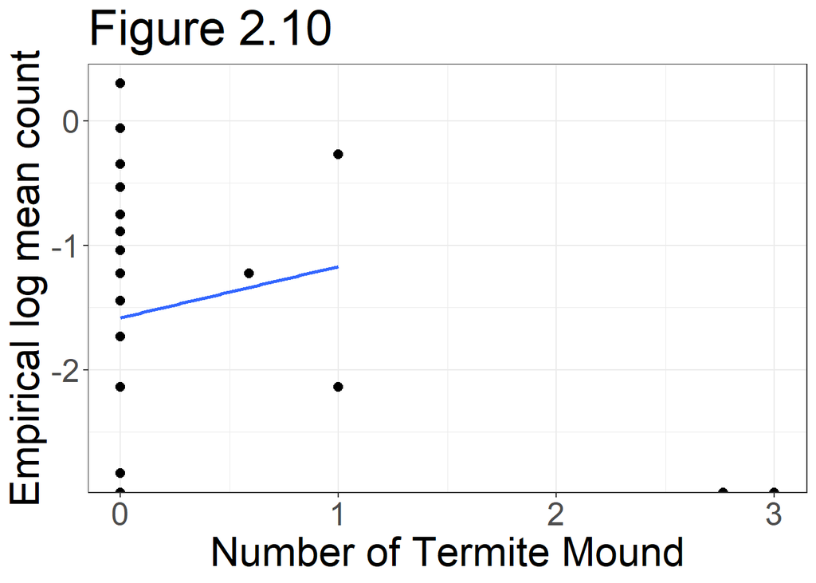

```r
logmean_plot(data = serengeti, 60, "equal_size", x = "TM100", y = "topi.count", reg_formula = y ~ x) + labs(title = "Figure 2.10", x = "Number of Termite Mound")
```

Based on Figure 2.10, no transformation is needed since it is hard to describe the shape.

[output not shown]

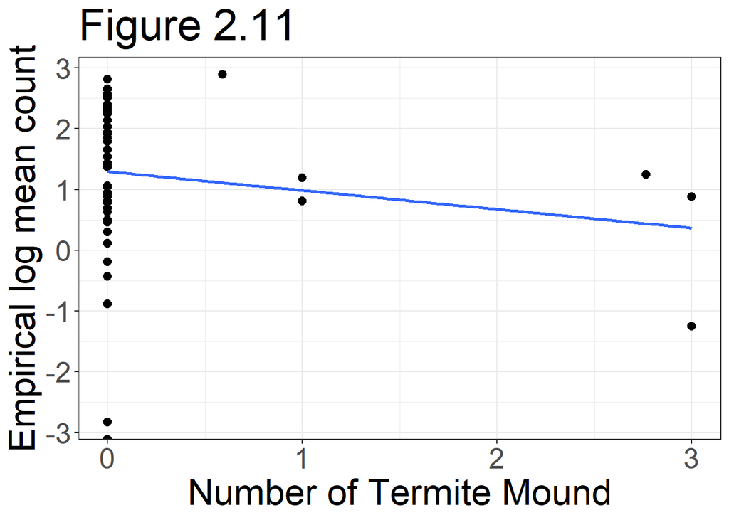

```r
logmean_plot(data = serengeti, 60, "equal_size", x = "TM100", y = "zebra.count", reg_formula = y ~ x) + labs(title = "Figure 2.11", x = "Number of Termite Mound")
```

Based on Figure 2.11, there is also no transformation needed for the relationship between the number of zebra and the number of termite mounds since most of the points is about around the line.

[output not shown]

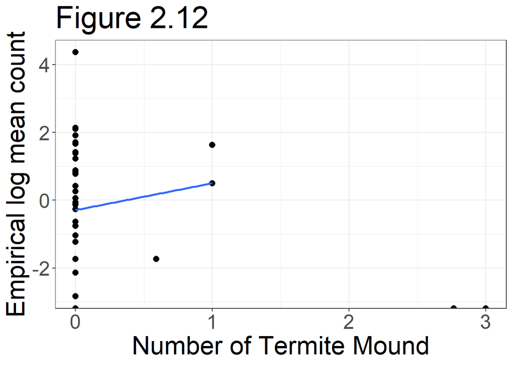

```r
logmean_plot(data = serengeti, 60, "equal_size", x = "TM100", y = "gazelleThomsons.count", reg_formula = y ~ x) + labs(title = "Figure 2.12", x = "Number of Termite Mound")
```

Based on the Figure 2.12, the relation between number of termite and the number of gazelle does not need to do any transformation.

[output not shown]

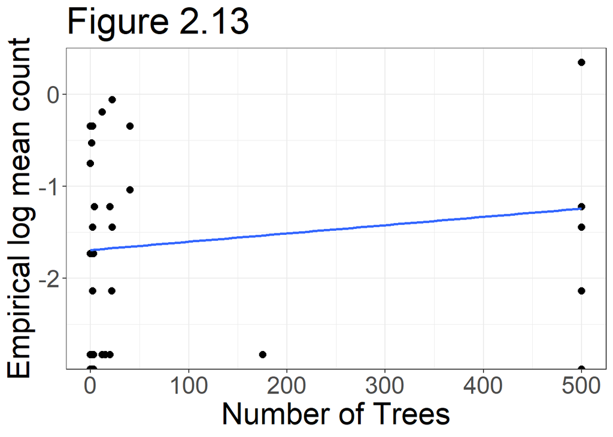

```r
logmean_plot(data = serengeti, 60, "equal_size", x = "T50", y = "topi.count", reg_formula = y ~ x) + labs(title = "Figure 2.13", x = "Number of Trees")
```

Based on the Figure 2.13, there is no transformation needed for the number of trees and the number of topi.

[output not shown]

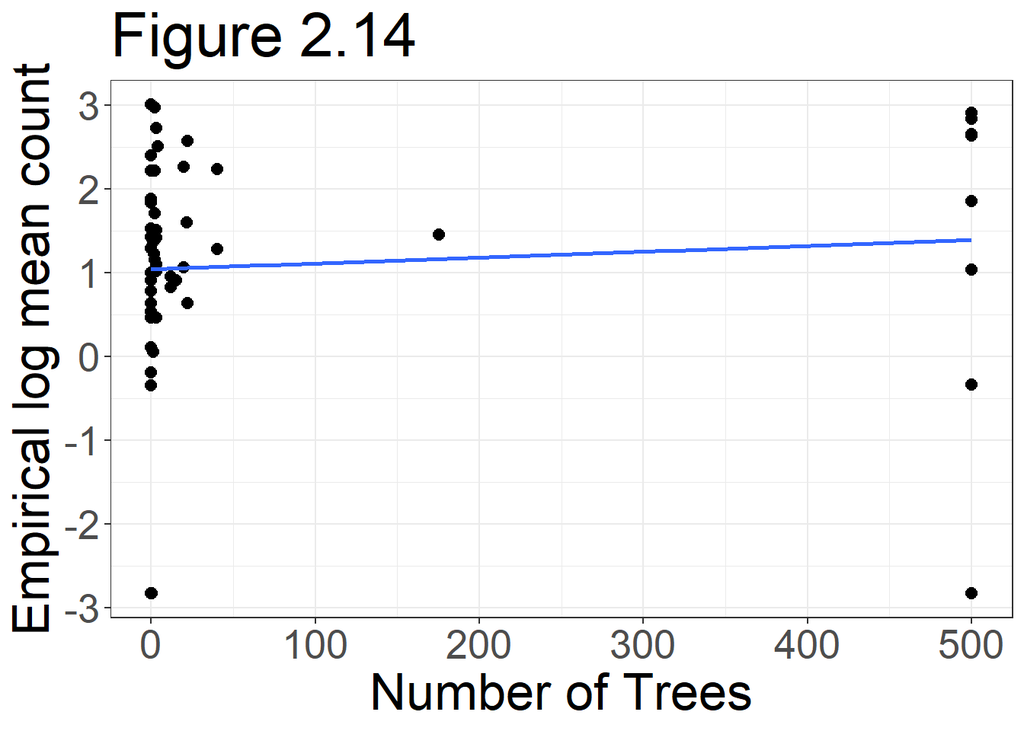

```r
logmean_plot(data = serengeti, 60, "equal_size", x = "T50", y = "zebra.count", reg_formula = y ~ x)  + labs(title = "Figure 2.14", x = "Number of Trees")
```

Based on Figure 2.14, no transformation is required for the number of trees and number of zebra.

[output not shown]

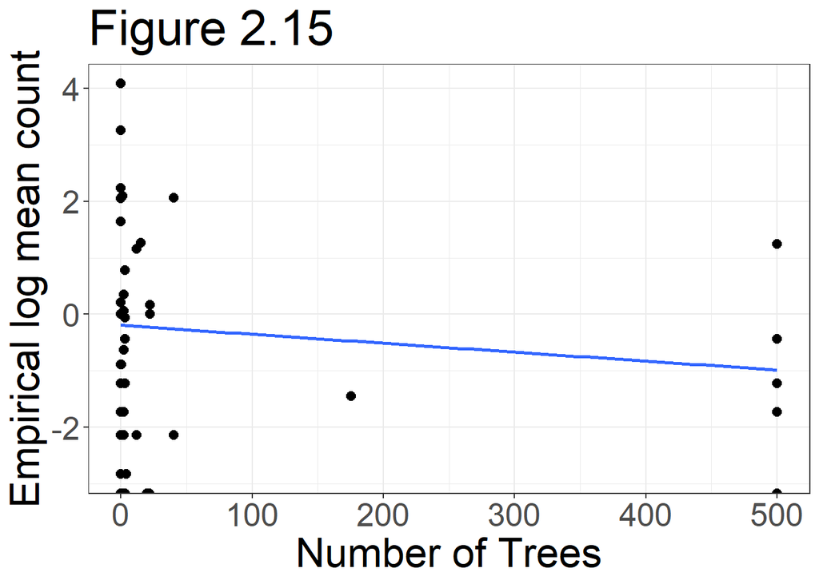

```r
logmean_plot(data = serengeti, 60, "equal_size", x = "T50", y = "gazelleThomsons.count", reg_formula = y ~ x)   + labs(title = "Figure 2.15", x = "Number of Trees")
```

As Figure 2.15 shows, only doing linear transformation for the relationship between number of gazelle and number treesis fine.

[output not shown]

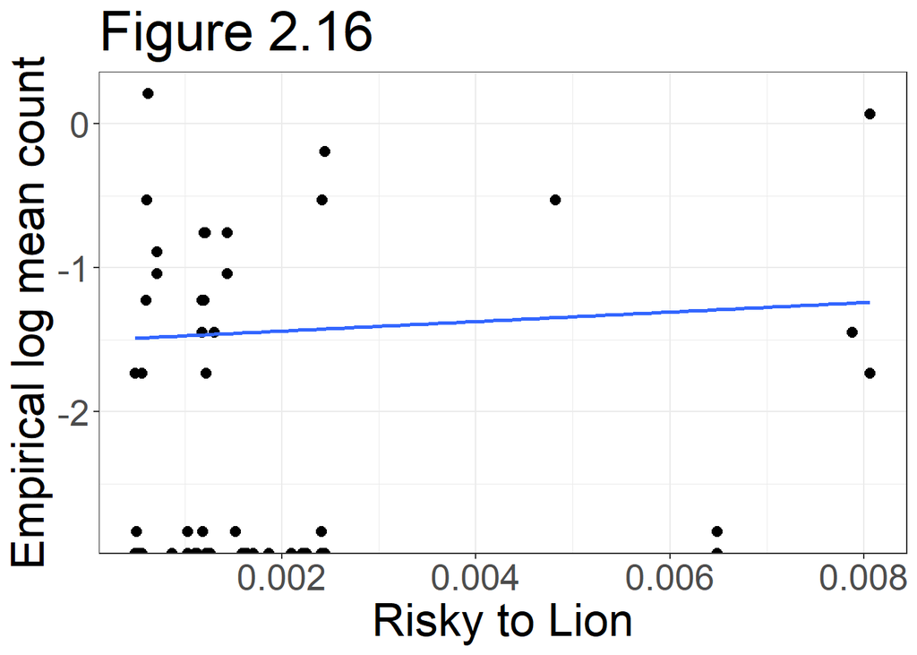

```r
logmean_plot(data = serengeti, 60, "equal_size", x = "LriskDry", y = "topi.count", reg_formula = y ~ x)  + labs(title = "Figure 2.16", x = "Risky to Lion")
```

As shown in Figure 2.16, it is reasonable to not have any transformation between the risk to lion and the number of topi.

[output not shown]

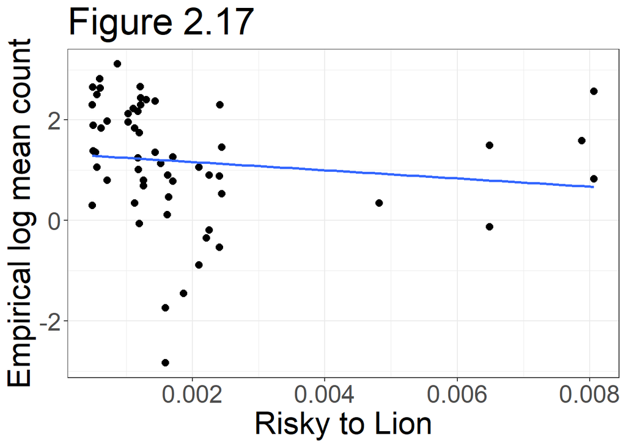

```r
logmean_plot(data = serengeti, 60, "equal_size", x = "LriskDry", y = "zebra.count", reg_formula = y ~ (x))  + labs(title = "Figure 2.17", x = "Risky to Lion")
```

Based on Figure 2.17, no transformation is needed for the relationship between the number of zebra and the risk to lion in certain site.

[output not shown]

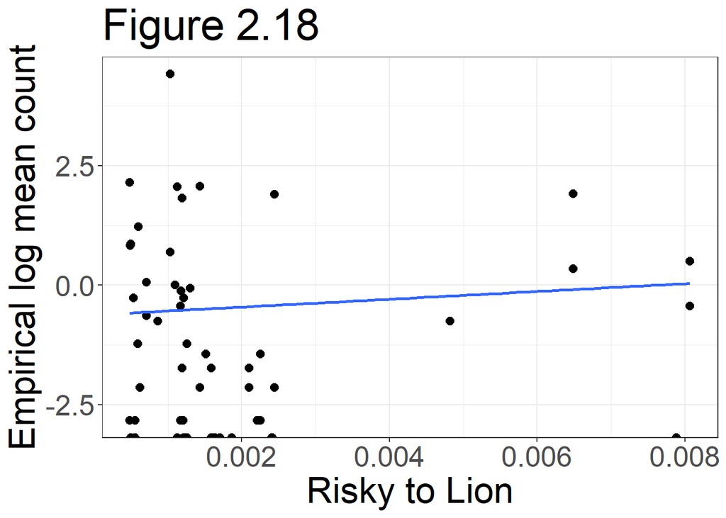

```r
logmean_plot(data = serengeti, 60, "equal_size", x = "LriskDry", y = "gazelleThomsons.count", reg_formula = y ~ (x)) +   labs(title = "Figure 2.18", x = "Risky to Lion")
```

From the Figure 2.18, it shows that just having linear transformation for the relation between the risk to lion and number of gazelle.

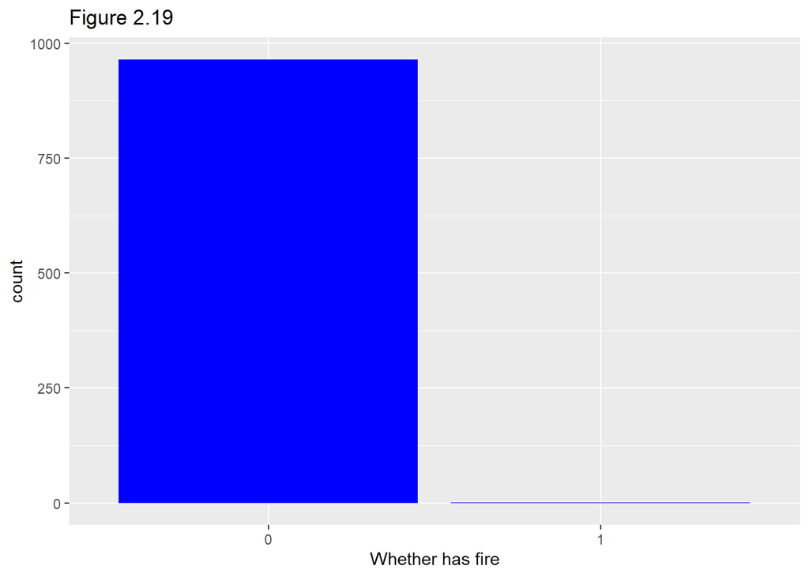

```r
serengeti <- serengeti %>%
  mutate(fire = as.factor(fire))
ggplot(data = serengeti, aes(x = fire)) + geom_bar(fill = "blue") + labs(title = "Figure 2.19", x = "Whether has fire")
```

Based on Figure 2.19, the $fire$ variable is very discrete and there is only one row showing that there is a wild fire. So this variable will not be chosen to include in the models since there is rarely relation between the number of species and whether has a wild fire.

## Section 3: Modeling

In the modeling section, since based on the Figure 2.1, 2.2, and 2.3 showed, three ZIP models for each species are required since there are excessive number of 0 in each species counts.

### Section 3.1: Importance of enviornment variables

For three different species, the population model will be the same. The population model for logistic regression part will be:
$$Z_i \sim Bernoulli(\alpha_i)$$
$$\log \left ( \frac{\alpha_i}{1-\alpha_i} \right )
= \gamma_0 + \gamma_1ndvi_i + \gamma_2log(amRivDist_i) + \gamma_3TM100_i
+ \gamma_4LriskDry_i + \gamma_5T50_i$$

The Poisson part will be:
$$Y_i \sim
Poisson(\lambda_i)$$

$$\log \left( \lambda_i \right) = \beta_0
+ \beta_1ndvi_i + \beta_2log(amRivDist_i) + \beta_3TM100_i +
\beta_4LriskDry_i + \beta_5T50_i$$

For specie topi, the summary for fitted regression model will be:

```r
zip_m1 <- zeroinfl(topi.count ~ ndvi + log(amRivDist) + TM100 + LriskDry + T50 | ndvi  + log(amRivDist) + TM100 + LriskDry + T50 , data = serengeti)
summary(zip_m1)
```

```
##
## Call:
## zeroinfl(formula = topi.count ~ ndvi + log(amRivDist) + TM100 + LriskDry +
##     T50 | ndvi + log(amRivDist) + TM100 + LriskDry + T50, data = serengeti)
##
## Pearson residuals:
##     Min      1Q  Median      3Q     Max
## -0.3873 -0.2630 -0.2072 -0.1744 14.8260
##
## Count model coefficients (poisson with log link):
##                  Estimate Std. Error z value Pr(>|z|)
## (Intercept)     1.7787610  0.5482199   3.245  0.00118 **
## ndvi           -0.2410404  0.7838326  -0.308  0.75845
## log(amRivDist) -0.1518015  0.0924268  -1.642  0.10051
## TM100          -0.2039337  0.4361713  -0.468  0.64010
## LriskDry       62.5114507 43.3208101   1.443  0.14902
## T50             0.0006309  0.0004607   1.369  0.17090
##
## Zero-inflation model coefficients (binomial with logit link):
##                  Estimate Std. Error z value Pr(>|z|)
## (Intercept)     1.889e+00  7.686e-01   2.457   0.0140 *
## ndvi           -1.252e+00  9.255e-01  -1.353   0.1761
## log(amRivDist)  2.414e-01  1.069e-01   2.258   0.0239 *
## TM100          -2.273e-01  3.864e-01  -0.588   0.5564
## LriskDry       -1.543e+02  6.399e+01  -2.411   0.0159 *
## T50            -1.106e-03  7.216e-04  -1.533   0.1252
## ---
## Signif. codes:  0 '***' 0.001 '**' 0.01 '*' 0.05 '.' 0.1 ' ' 1
##
## Number of iterations in BFGS optimization: 51
## Log-likelihood: -355.8 on 12 Df
```

```r
zip_m2 <- zeroinfl(zebra.count ~ ndvi + log(amRivDist) + TM100 + LriskDry + T50 | ndvi + log(amRivDist) + TM100 + LriskDry + T50, data = serengeti)
summary(zip_m2)
```

```
##
## Call:
## zeroinfl(formula = zebra.count ~ ndvi + log(amRivDist) + TM100 + LriskDry +
##     T50 | ndvi + log(amRivDist) + TM100 + LriskDry + T50, data = serengeti)
##
## Pearson residuals:
##     Min      1Q  Median      3Q     Max
## -1.0084 -0.7021 -0.6319 -0.4372 21.5623
##
## Count model coefficients (poisson with log link):
##                  Estimate Std. Error z value Pr(>|z|)
## (Intercept)     3.157e+00  8.750e-02  36.081  < 2e-16 ***
## ndvi           -5.754e-01  1.241e-01  -4.638 3.52e-06 ***
## log(amRivDist) -2.147e-02  1.045e-02  -2.054  0.03998 *
## TM100          -1.495e-01  3.819e-02  -3.915 9.04e-05 ***
## LriskDry       -2.370e+01  8.717e+00  -2.719  0.00656 **
## T50             6.357e-04  6.788e-05   9.366  < 2e-16 ***
##
## Zero-inflation model coefficients (binomial with logit link):
##                  Estimate Std. Error z value Pr(>|z|)
## (Intercept)    -0.2918755  0.4254475  -0.686   0.4927
## ndvi            0.4669307  0.4721446   0.989   0.3227
## log(amRivDist)  0.0946277  0.0551052   1.717   0.0859 .
## TM100           0.2160096  0.1271947   1.698   0.0895 .
## LriskDry       65.8485699 40.0229812   1.645   0.0999 .
## T50            -0.0010562  0.0003903  -2.706   0.0068 **
## ---
## Signif. codes:  0 '***' 0.001 '**' 0.01 '*' 0.05 '.' 0.1 ' ' 1
##
## Number of iterations in BFGS optimization: 1
## Log-likelihood: -5759 on 12 Df
```

For specie zebra, the fitted regression line will be:
$$\log \left ( \frac{\alpha_i}{1-\alpha_i} \right )
= -0.2919 + 0.467ndvi_i + 0.0946log(amRivDist_i)+0.216TM100_i +
65.8486riskDry_i - 0.0011T50_i$$
$$\log \left( \lambda_i \right) = 3.157 -
0.5754ndvi_i -0.0215log(amRivDist_i) -0.1495TM100_i - 23.7LriskDry_i
+0.0006T50_i$$

The summary fitted regresion model for specie gazelle will be:

```r
zip_m3 <- zeroinfl(gazelleThomsons.count ~ ndvi + log(amRivDist) + TM100 + LriskDry + T50  | ndvi + log(amRivDist) + TM100 + LriskDry + T50, data = serengeti)
summary(zip_m3)
```

```
##
## Call:
## zeroinfl(formula = gazelleThomsons.count ~ ndvi + log(amRivDist) + TM100 +
##     LriskDry + T50 | ndvi + log(amRivDist) + TM100 + LriskDry + T50,
##     data = serengeti)
##
## Pearson residuals:
##     Min      1Q  Median      3Q     Max
## -1.3405 -0.4588 -0.3266 -0.2035 29.1032
##
## Count model coefficients (poisson with log link):
##                  Estimate Std. Error z value Pr(>|z|)
## (Intercept)    -4.223e-02  2.138e-01  -0.198    0.843
## ndvi           -2.816e+00  2.269e-01 -12.411  < 2e-16 ***
## log(amRivDist)  5.595e-01  2.587e-02  21.626  < 2e-16 ***
## TM100          -3.943e-01  9.618e-02  -4.100 4.13e-05 ***
## LriskDry       -1.023e+02  1.191e+01  -8.589  < 2e-16 ***
## T50            -2.613e-03  2.306e-04 -11.328  < 2e-16 ***
##
## Zero-inflation model coefficients (binomial with logit link):
##                  Estimate Std. Error z value Pr(>|z|)
## (Intercept)     5.805e-01  6.359e-01   0.913  0.36128
## ndvi            5.235e+00  7.768e-01   6.740 1.59e-11 ***
## log(amRivDist) -1.815e-01  8.136e-02  -2.231  0.02567 *
## TM100           6.865e-01  2.391e-01   2.872  0.00408 **
## LriskDry        4.370e+01  5.158e+01   0.847  0.39686
## T50             3.001e-05  5.528e-04   0.054  0.95671
## ---
## Signif. codes:  0 '***' 0.001 '**' 0.01 '*' 0.05 '.' 0.1 ' ' 1
##
## Number of iterations in BFGS optimization: 26
## Log-likelihood: -2964 on 12 Df
```

The fitted regression line for gazelle will be:
$$\log \left ( \frac{\alpha_i}{1-\alpha_i} \right )
= 0.5805 + 5.235ndvi_i - 0.1815log(amRivDist_i) + 0.6865TM100_i +
43.7LriskDry_i + 0.00003T50_i$$
$$\log
\left( \lambda_i \right) = -0.0422 -2.816ndvi_i + 0.5595log(amRivDist_i)
-0.3943TM100_i - 102.3LriskDry_i - 0.0026T50_i$$

#### Test 1

```r
zip_m3$loglik
```

```
## [1] -2963.71
```

The log likelihood for the reduced model will be:

```r
zip_m4 <- zeroinfl(gazelleThomsons.count ~  log(amRivDist) + TM100 + LriskDry + T50  | ndvi + log(amRivDist) + TM100 + LriskDry + T50, data = serengeti)
zip_m4$loglik
```

```
## [1] -3048.128
```

The test statistic $G$ will be $2(-2963.71-(-3048.128)) = 168.836$

Using $\chi^2$ distribution, the p-value will be

```r
pchisq(168.836, df = 1, lower.tail = FALSE)
```

```
## [1] 1.32862e-38
```

### Section 3.2: Comparing species

## Section 4: Discussion